# MA8701: Advanced statistical methods in inference and learning

Project 1: Analysis using shrinkage methods

Janne Cathrin Hetle Aspheim

Philip Stanley Mostert

Kenneth Aase

Group: JKP

27 March 2023

# Introduction

Evolutionary ecologists are interested in understanding the variation in the genetic architecture of populations of species in order to determine the traits which drive the fitness of a species. To do so, they use statistical analyses to study single nucleotide polymorphisms (SNPs) common across a population. These SNPs represent a variation at a specific position in a DNA sequence and are indicative of the genetic diversity among individuals in the same population.

In this analysis we use SNP data collected of house sparrow (*Passer domesticus*) on 8 islands at the Helgeland coast (Norway), studied in Niskanen et al. (2020). These data have been collected since 1993 and contains a wide variety of different information: pedigree, genetic alongside morphological and life-history data (Lundregan et al. 2018).

For this project, we focus on studying the genetic architecture of the house sparrows, analyzing which SNPs have a significant effect on the wing length of the sparrows (at age 1). Genomic data is usually characterized by a large numbers of SNPs, which makes finding their effects on the response difficult. As a result, we will here use lasso regularization and multiple sample splitting techniques to compute the *p-values* for the effects of the SNPs. We will also correct for the effects of sex, hatch year, island of measurement and inbreeding coefficient (`FGRM`), and these non-SNP covariates will not be penalized in the lasso.

## Prerequisites

`glmnet` (Friedman, Hastie, and Tibshirani 2010) is a popular *R* package to fit lasso regression effectively. However, the package struggles when both the sample size and number of predictor variables is incredibly large. As a result, we use `snpnet` (Qian, Hastie, and Tanigawa 2023), which is a bespoke *R* package designed to fit penalizing regression methods for individual-level genetic data such as those used in this example. `snpnet` is not on CRAN, and must therefore be installed using the following instructions provided [here](https://github.com/junyangq/snpnet).

```r
library(devtools)

# First, install dependencies that are not on CRAN
install_github("junyangq/glmnetPlus", dependencies = TRUE)
## if this ^ does not work, run
## curl -LO http://r.research.att.com/libs/gfortran-4.8.2-darwin13.tar.bz2
## sudo tar fvxj gfortran-4.8.2-darwin13.tar.bz2 -C /
# in the terminal and then try again.


install_github("chrchang/plink-ng", subdir="/2.0/cindex", dependencies = TRUE)
install_github("chrchang/plink-ng", subdir="/2.0/pgenlibr", dependencies = TRUE)

# Now install snpnet
install_github("junyangq/snpnet", dependencies = TRUE)
```

## Data

### Genomic data

We will use the full SNP data set, in the files `Genotypes.map` and `Genotypes.ped`. We first prepare the data using PLINK v2. To run our code, you need to download the genomic data and phenotype data from Niskanen et al. (2023) and the program `plink2` from [here](https://www.cog-genomics.org/plink/2.0/) and put it in your working folder. We do some standard quality control steps (remove SNPs with minor allele frequency lower than $0.01$, remove SNPs missing in more than $10\%$ of individuals and remove individuals missing more than $5\%$ of the SNPs). These steps are performed to avoid including markers or individuals whose genotyping was unsuccessful in the analysis (Choi, Mak, and O’Reilly 2020). We also change the dataset to the input format that `snpnet` needs.

```r
system2("./plink2", "--pedmap doi_10.5061_dryad.m0cfxpp10__v10/Genotypes --chr-set 32 --out sparrow_snps --maf 0.01 --geno 0.1 --mind 0.05 --make-pgen vzs")
```

Running this script shows that we have 183155 SNPs to use in our analysis. For memory reasons, the full data set will not be loaded into the *R* session, and so no graphical summary is available on them.

### Phenotype data

In this section we prepare the phenotype data (age 1 wing length).

```r
# Load the data
library(dplyr)

df <- read.table("doi_10.5061_dryad.m0cfxpp10__v10/Data.txt",
                 header = T)

response = "age1wing"

df2 <- select(df[!is.na(df[, response]), ], c(response, "FGRM", "gen_sex", "all_hatchyears", "fiflok"))
```

We create some columns to indicate our cross-validation splits.

```r
set.seed(8701)
num_folds <- 10
df2[paste0("fold", 1:num_folds)] = NA
s <- dim(df2)[1] %>%
  seq_len() %>%
  sample() %>%
  cut(breaks = num_folds)
df2[, paste0("fold", 1:num_folds)] <-
  sapply(1:10, function(fold) ifelse(s == levels(s)[fold], "val", "train"))
```

We add the non-penalized covariates to the data.

```r
df2 <- cbind(data.frame(FID = 1, IID = df$id[!is.na(df[, response])]), df2)
df2$gen_sex <- as.factor(df2$gen_sex)
df2$all_hatchyears <- as.factor(df2$all_hatchyears)
df2$fiflok <- as.factor(df2$fiflok)
# Create dummy variables since snpnet() and plink are not as smart as lm()
X <- model.matrix(get(response) ~ gen_sex + all_hatchyears + fiflok,
                  data = df2, )[, -1]
covs <- c("FGRM", colnames(X))
df2[, covs[-1]] <- X
```

Finally, we make the phenotype file that snpnet needs.

```r
write.table(df2,
            file = paste0("pheno_", response, ".txt"),
            row.names = F,
            quote = F)
```

Looking at the dimensions of our data, we see that we have 1796 observations of wing length, and 23 non-SNP covariates in the model.

```r
dim(df2[, covs[-1]])
```

```
## [1] 1796   23
```

Various descriptive plots of the response variable are given below.

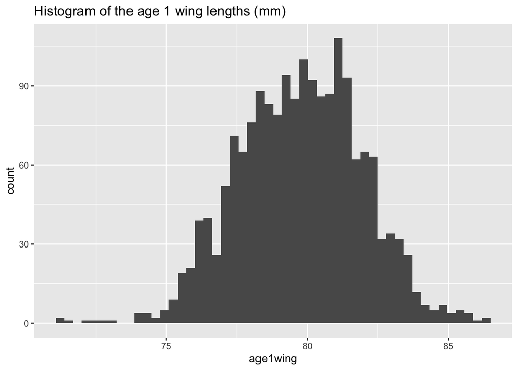

```r
library(ggplot2)

ggplot(data = df2, aes(x = age1wing)) +
  geom_histogram(bins = 50) +
  ggtitle('Histogram of the age 1 wing lengths (mm)')
```

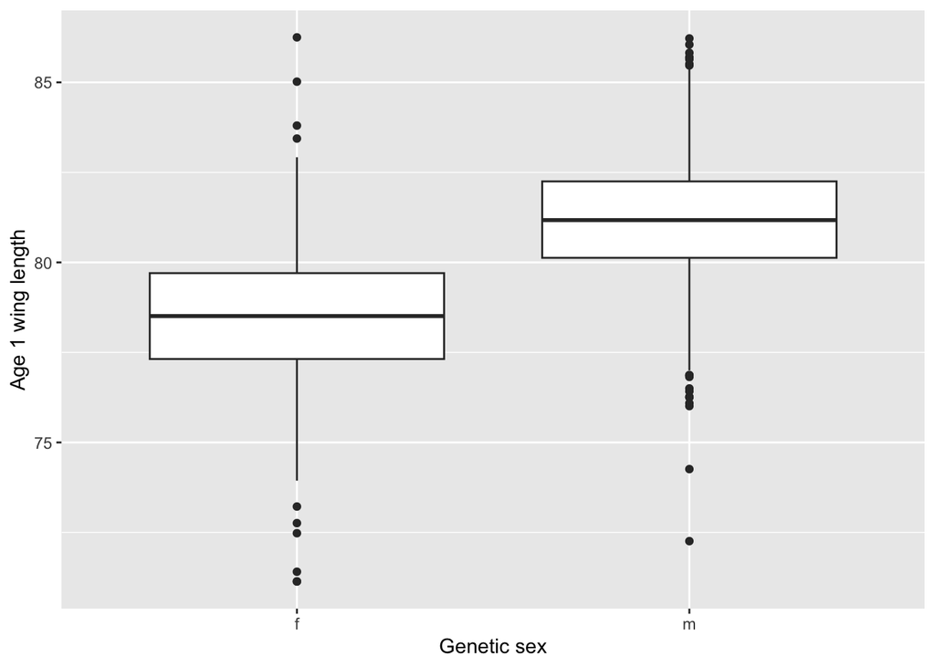

```r
ggplot(data = df2, aes(y = age1wing, x = factor(gen_sex))) +
  geom_boxplot() +
  xlab("Genetic sex") +
  ylab("Age 1 wing length")
```

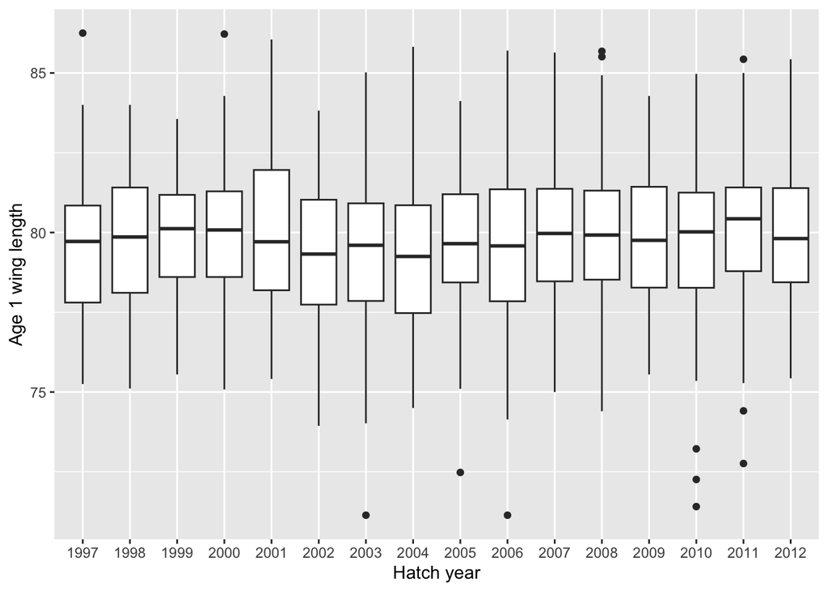

```r
ggplot(data = df2, aes(y = age1wing, x = factor(all_hatchyears))) +
  geom_boxplot() +
  xlab("Hatch year") +
  ylab("Age 1 wing length")
```

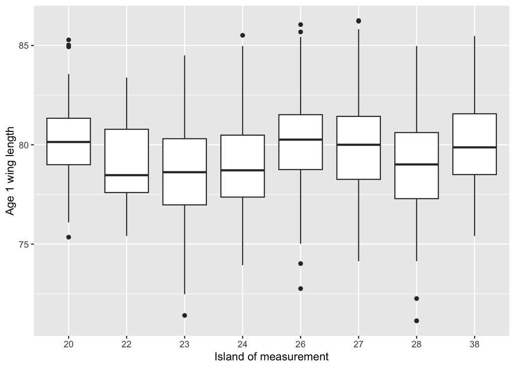

```r
ggplot(data = df2, aes(y = age1wing, x = factor(fiflok))) +
  geom_boxplot() +
  xlab("Island of measurement") +
  ylab("Age 1 wing length")
```

The mean of the age 1 wing lengths is 79.74mm with a standard deviation of 2.19mm.

Next, we check the linear model assumptions for the base model with no SNPs included as covariates.

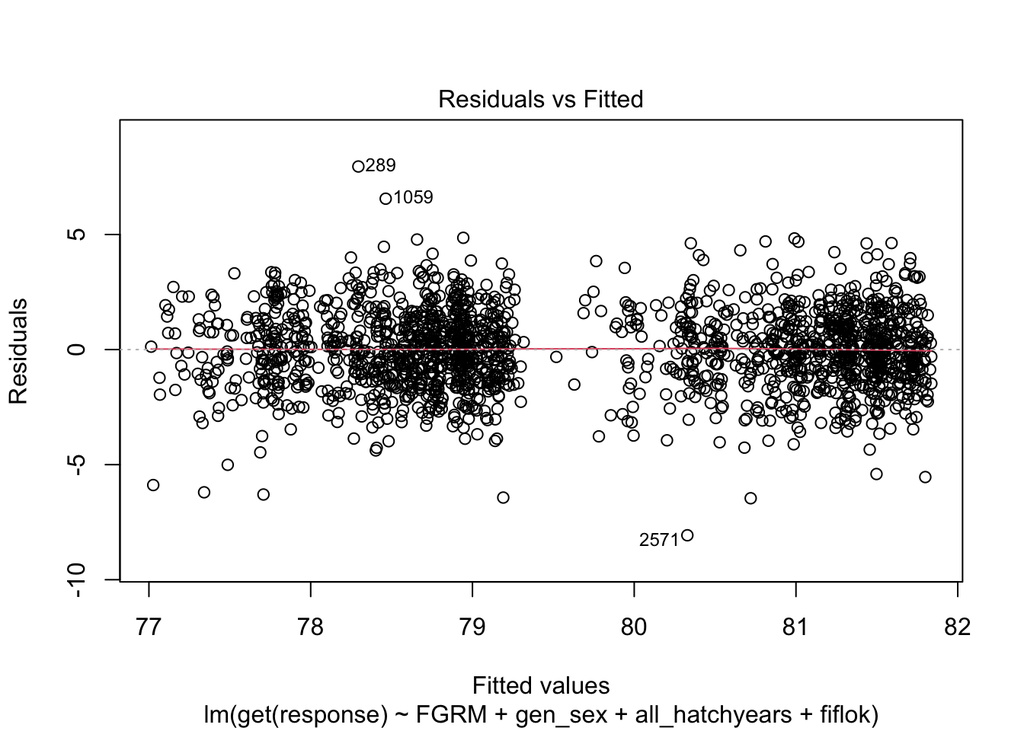

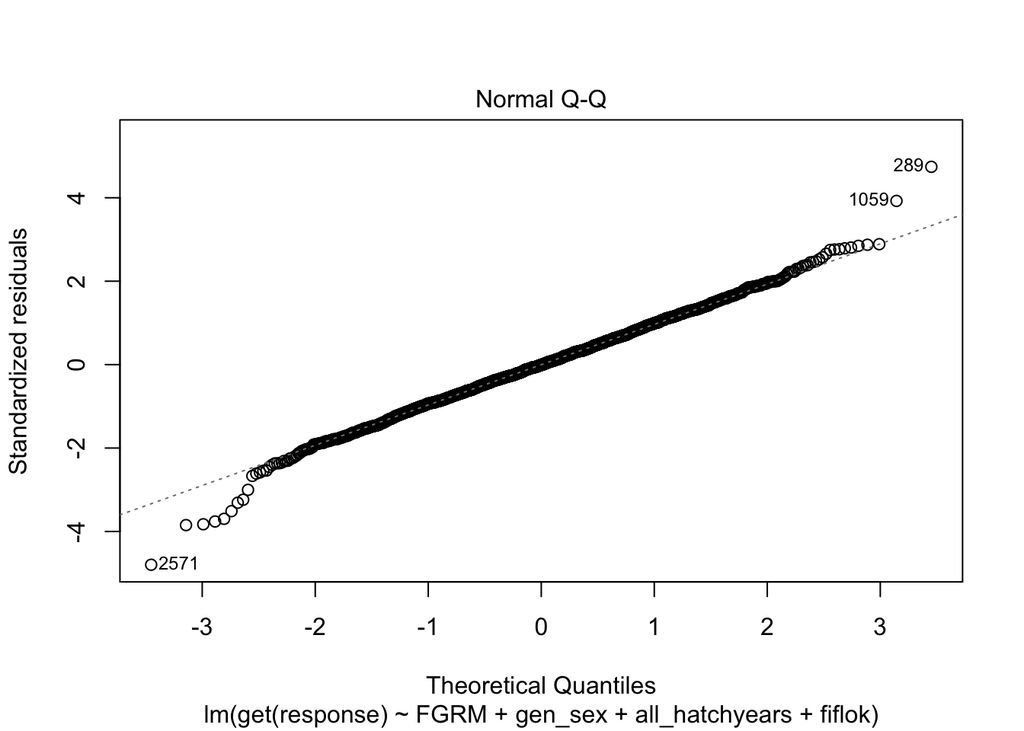

```r
# MLR on full data set, no SNPs.
# gen_sex, all_hatchyears, fiflok (island of measurement) are categorical, with
# 2, 16 and 8 levels, respectively, while FGRM (inbreeding coef.) is continuous
non_snp_mod <- lm(get(response) ~ FGRM + gen_sex + all_hatchyears + fiflok,
                  data = df2)

# Check model assumptions
plot(non_snp_mod, which = c(1, 2))
```

Based on the residuals vs. fitted plot and the normal QQ-plot the linear regression assumptions seem to be fine The reason we get two “bands” of fitted values in the residual vs. fitted plot is that the male sparrows generally have longer wings than the females, as seen in an earlier plot. The non-SNP covariates give an $R^2$ of 0.41.

## Introduction to methods

The aim of this analysis is to perform dimension reduction on the dataset to find a small subset of relevant SNPs; to do so we consider lasso regression. To define lasso regression, we let $n$ be the number of observations, $p$ be the number of covariates, and consider the standard regression setup using matrix notation:

$$\boldsymbol{Y} = \boldsymbol{X}\boldsymbol{\beta}
+\boldsymbol{\epsilon},$$

where:

- $\boldsymbol{Y}$ is a $n\times1$ vector of response variables (in our example the wing length),
- $\boldsymbol{X}$ is a $n\times p$ design matrix with rows of observations and columns of covariates (in our example the SNPs),
- $\boldsymbol{\beta}$ is a $n\times1$ vector of regression coefficients and
- $\boldsymbol{\epsilon}$ is a $n\times1$ vector of random error.

The aim at hand is to choose a subset of $\boldsymbol{\beta}$ that exhibit the strongest effect. We do this by imposing some shrinkage term on the $\boldsymbol{\beta}$’s, such that some of them are set to $0$. We then define the lasso coefficients as ones which minimize a penalized residual sum of squares.

$$\hat{\boldsymbol{\beta}}_{lasso} =
\text{argmin}_{\boldsymbol{\beta}}\left(\frac{1}{n}\left|\left|\boldsymbol{Y}
- \boldsymbol{X}\boldsymbol{\beta}\right|\right|^2_2\right)$$

subject to $\left|\left|\boldsymbol{\beta}\right|\right|_1 \le t$. Or using Lagrangian notation gives:

$$\hat{\boldsymbol{\beta}}_{lasso} = argmin_{\boldsymbol{\beta}}\left(
\frac{1}{n}\left|\left|\boldsymbol{Y} -
\boldsymbol{X}\boldsymbol{\beta}\right|\right|^2_2 -
\lambda\left|\left|\boldsymbol{\beta}\right|\right|_1\right),$$
where $\lambda \ge 0$ is the term which controls shrinkage.

After performing lasso regression, we are interested in determining the statistical strength of the selected SNPs. However doing this is difficult given that lasso regression already introduces a selection procedure on the variables. As a result, we consider multiple sample splitting to obtain p-values for the SNPs selected from lasso. Multiple sample-splitting is a method for constructing hypothesis tests when the number of covariates are high. Full details are provided in (Dezeure et al. 2015), and so we only show the algorithm for which to obtain the p-values below. The first step is finding corrected p-values using the single-sample splitting method, and then correcting them again using the multiple-sampling splitting procedure (which we do in order to account for the fact that the p-values selected in the former method are sensitive to the split of the data).

Single-sample splitting:

1. Split the data in half, $I_1$ and $I_2$ where no observations are common between the two.
2. Use $I_1$ for model selection with the lasso, with active variables $\hat{S}\left(I_1\right)$.
3. Use the variables in $\hat{S}\left(I_1\right)$ to conduct estimation using data $I_2$ with least-squares, and find $m$ p-values for the estimated coefficients. For missing genotypes, we use replace the missing SNP count with the allele frequency, in other words mean imputation.
4. Correct the $j^{th}$ raw p-values for multiple testing using: $P_{corr, j} = min\left(P_j * \left|\hat{S}\left(I_1\right)\right|,1 \right)$.

Multiple-sample splitting:

1. Run the single sample splitting $B$ times to obtain $P_{corr, j}^{[b]}$ for $b = 1,2,…,B$ and $j = 1,2,…,m$.
2. Then calculate $Q_j \left({\gamma}\right) = \min \left( 1, \text{quantile}_\gamma\left(P_{corr, j}^{[b]}/\gamma \right)_{b=1}^B\right)$ , for values of $\gamma$ in $(\gamma_\text{min} , 1)$, where $\gamma_\text{min}$ is typically $0.05$.
3. Finally, correct for trying many different values of $\gamma$ by multiplying by $(1 - \log(\gamma_\text{min}))$, to obtain the final FWER-adjusted p-values:
   $$\text{p-value}_j = \min(1, (1 - \log(\gamma_\text{min}))\cdot
   \min_\gamma( Q_j \left({\gamma}\right)))$$

## Statistical analysis

### Cross-validation for lasso parameter

When performing lasso-regression we need to choose a value for the penalization parameter $\lambda$. We use 10-fold cross-validation for this. Preferably the cross-validation loop should happen inside the multiple sample-splitting procedure to generate a new $\lambda$ for each split to avoid data leakage, but in the interest of computational time we pre-compute a global $\lambda$ to be used in all splits. Below is the code for the cross-validation for $\lambda$.

```r
library(snpnet)

configs <- list(
    early.stopping = FALSE,
    plink2.path = "./plink2",
    zstdcat.path = "zstdcat"
)


configs$nCores <- parallel::detectCores() - 1
configs$use.glmnetPlus <- TRUE
configs$early.stopping <- FALSE
configs$stopping.lag <- 100
configs$verbose <- FALSE

# Full solution path
full_model <- snpnet(genotype.pfile = "sparrow_snps",
                     phenotype.file = paste0("pheno_", response, ".txt"),
                     phenotype = response,
                     # # Add fixed unpenalized effects here
                     covariates = covs,
                     # alpha = 1 means lasso, 0 means ridge, elastic net between
                     alpha = 1,
                     nlambda = 100, # How many values of lambda to try
                     split.col = NULL, # no validation
                     configs = configs)

# Cross-validation
result <- vector("list", num_folds)
for (k in 1:num_folds) {
  model <- snpnet(genotype.pfile = "sparrow_snps",
                  phenotype.file = paste0("pheno_", response, ".txt"),
                  phenotype = response,
                  covariates = covs, # Add fixed unpenalized effects here
                  # alpha = 1 means lasso, 0 means ridge, elastic net between
                  alpha = 1,
                  lambda = full_model$full.lams, # Check same lambdas as full
                  split.col = paste0("fold", k), # Cross-validation columns
                  configs = configs)
  result[[k]] <- model
}

# Choose best lambda
cv_metric <- rowMeans(sapply(result, function(res) res$metric.val))
opt_idx <- which.max(cv_metric) # metric: R^2 in val. set
opt_lambda <- full_model$full.lams[opt_idx]

# Non-zero betas in optimal model
opt_betas <- full_model$beta[[opt_idx]][full_model$beta[[opt_idx]] != 0]

# Save CV result
save(full_model,
     cv_metric,
     opt_idx,
     opt_lambda,
     opt_betas,
     file = paste0("cv_model_", response, ".RData"))
```

### Multiple sample splitting

Below we perform the multiple sample splitting and generate FWER-adjusted p-values.

```r
configs$early.stopping <- TRUE
B <- 1e3
p_values_split <- vector("list", B)

for (b in 1:B) {
  # Split sample in two
  split <- sample(x = df2$IID, size = round(length(df2$IID) / 2))

  # Write file for lasso-half of sample
  write.table(df2[df2$IID %in% split, ],
              file = paste0("pheno_ss_", response, ".txt"),
              row.names = F,
              quote = F)

  # Lasso-model with a given lambda
  ss_model <- snpnet(genotype.pfile = "sparrow_snps",
                     phenotype.file = paste0("pheno_ss_", response, ".txt"),
                     phenotype = response,
                     # Fixed effects
                     covariates = covs,
                     # alpha = 1 means lasso, 0 means ridge, elastic net between
                     alpha = 1,
                     lambda = opt_lambda, # Use optimal lambda
                     split.col = NULL, # cross-validation
                     configs = configs)

  # Non-zero betas
  ss_betas <-  ss_model$beta[[1]][ss_model$beta[[1]] != 0][-(1:(length(covs)))]

  # Write phenotype file for least squares half of sample
  write.table(df2[!df2$IID %in% split, ],
              file = paste0("pheno_ss!_", response, ".txt"),
              row.names = F,
              quote = F)

  # Write genomic file for least squares half of sample
  system2("./plink2",
          paste0("--pfile vzs sparrow_snps --snps ",
                 paste(substr(names(ss_betas),
                              start = 1,
                              stop = nchar(names(ss_betas)) - 2),
                       collapse = ", "),
                 " --pheno ", paste0("pheno_ss!_", response, ".txt"),
                 " --pheno-name ", response,
                 " --export A",
                 " --require-pheno ", response,
                 " --freq",
                 " --out chosen_snps"))

  # Load genomic data
  raw <- data.table::fread(file = "chosen_snps.raw",
                           drop = c(1, 3, 4, 5),
                           data.table = FALSE)
  # Load allele frequencies
  freqs <- data.table::fread(file = "chosen_snps.afreq",
                             select = "ALT_FREQS",
                             data.table = FALSE)

  # Mean imputation
  for (snp in seq_len(ncol(raw))[-(1:2)]) {
    raw[is.na(raw[, snp]), snp] <- 2 * (1 - freqs[snp - 2, ])
  }

  # Data object for linear regression
  ls_df <- cbind(df2[match(raw$IID, df2$IID), c(covs)],
                 raw[, !colnames(raw) %in% "IID"])

  # Perform linear regression
  ls_mod <- lm(PHENOTYPE ~ ., data = ls_df)
  # Save SNP p-values
  p_v <- summary(ls_mod)$coefficients[, "Pr(>|t|)"]
  p_v <- p_v[substr(names(p_v), 1, 3) == "SNP"]
  p_values_split[[b]] <- data.frame(ID = names(p_v),
                                    # Correct for multiple testing
                                    P_corr = pmin(p_v * length(p_v), 1))
  # Garbage collection
  rm(ls_mod, raw, ss_model, ls_df, p_v)
  gc()
}

# All SNPs with non-zero beta in at least one split
atleastonce <- unique(unlist(sapply(p_values_split, function(p) p$ID)))

# Combine results from splits
p_values_split_combined <- lapply(p_values_split, function(x) {

  df <- data.frame(p_val = rep(1, length(atleastonce))) # Non-chosen p-values=1
  rownames(df) <- atleastonce

  # Record p-values for chosen SNPs
  for (snp in x$ID) {
    df$p_val[rownames(df) == snp] <- x$P_corr[x$ID == snp]
  }

  df
}) %>%
  do.call(what = cbind)

colnames(p_values_split_combined) <-
  paste0(colnames(p_values_split_combined), "_", 1:B)

# Find Q_gamma for various values of gamma (i.e. correct for multiple splitting)
gamma_min <- 0.05 # Minimum quantile we check
gamma <- seq(from = gamma_min, by = 0.01, to = 1)
Q_gamma <- as.data.frame(lapply(X = gamma,
                                FUN = function(g) {
                                  apply(X = p_values_split_combined / g,
                                        MARGIN = 1,
                                        FUN = function(x) {
                                          min(quantile(x, probs = g), 1)
                                        })}),
                         col.names = gamma,
                         row.names = atleastonce)

# Choose gamma for each SNP, and correct for the choice by multiplying
# with (1 - log(gamma_min))
P_val_final <- pmin(1, apply(as.data.frame(Q_gamma), MARGIN = 1, FUN = min) *
                      (1 - log(gamma_min)))

names(P_val_final) <- atleastonce

# Save results
save(p_values_split_combined,
     Q_gamma,
     P_val_final,
     file = "sample_splitting_results.RData")
```

## Results

```r
summary(P_val_final)
```

```
##    Min. 1st Qu.  Median    Mean 3rd Qu.    Max.
##       1       1       1       1       1       1
```

The final FWER-adjusted p-values for all SNP-effects equal $1$, we essentially find a null result. Below we provide some miscellaneous plots from the results.

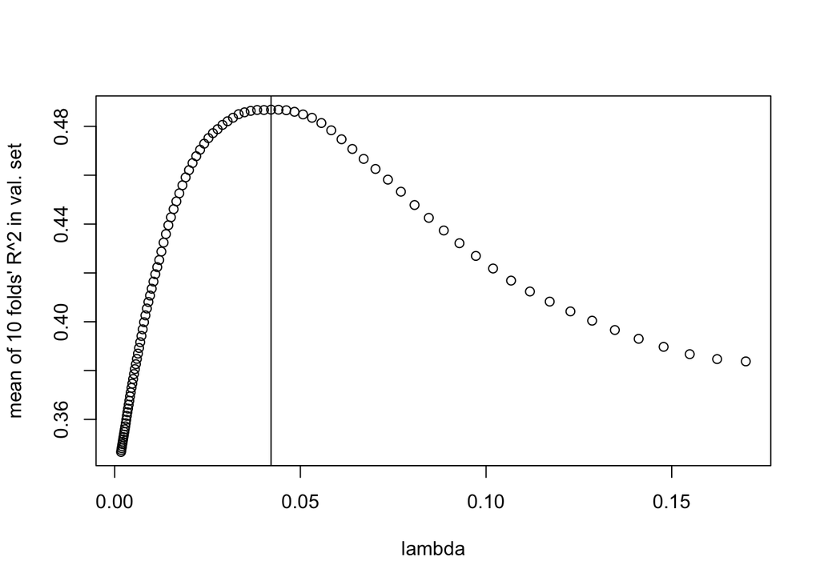

```r
plot(full_model$full.lams,
     cv_metric,
     xlab = "lambda",
     ylab = "mean of 10 folds' R^2 in val. set")
abline(v = opt_lambda)
```

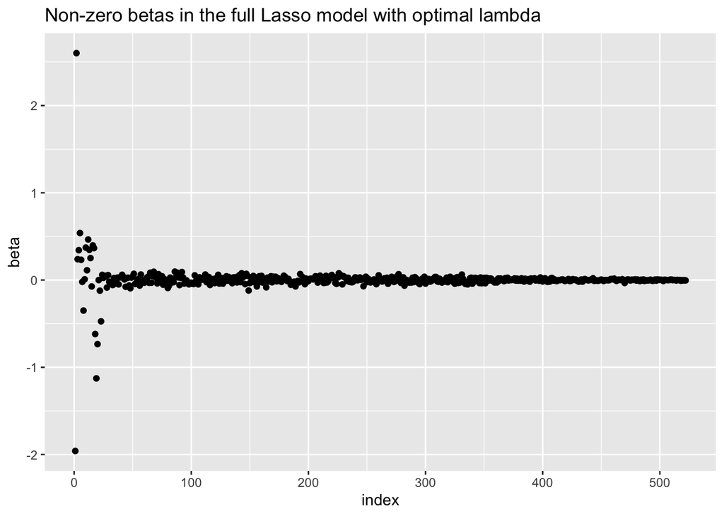

```r
ggplot(map = aes(x = 1:length(opt_betas), y = opt_betas)) +
  geom_point() +
  ylab("beta") +
  xlab("index") +
  ggtitle("Non-zero betas in the full Lasso model with optimal lambda")
```

Before the Bonferroni-correction, the number of raw p-values that are $<1$ are around 300-500 in each split (results not shown). After the Bonferroni-correction, the number of corrected p-values that are $<1$ in a given split is shown in the figure below.

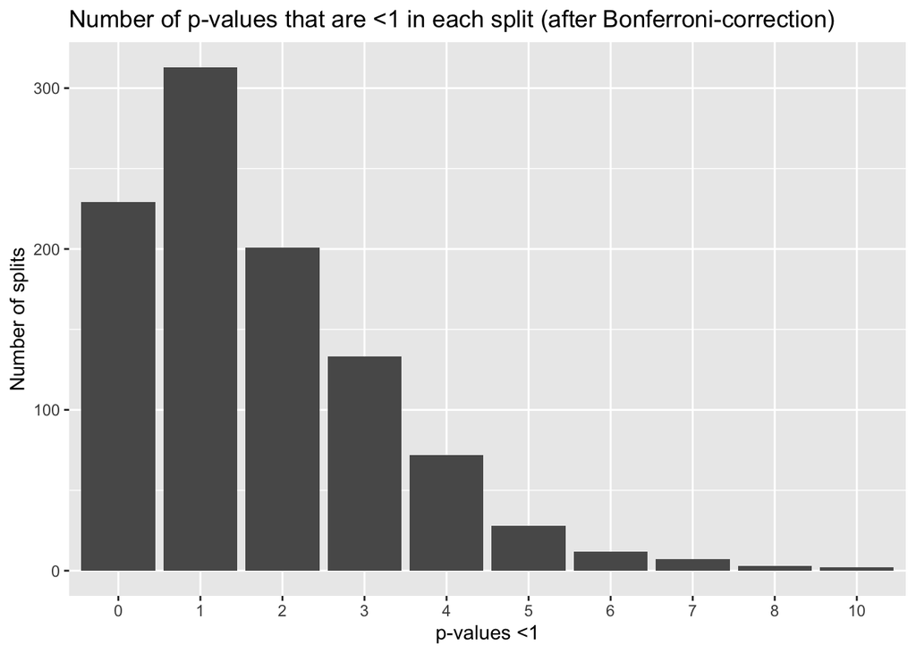

```r
num_non1 <- apply(p_values_split_combined, 2, function(x) sum(x != 1))

ggplot(map = aes(x = as.factor(num_non1))) +
  geom_bar() +
  ggtitle("Number of p-values that are <1 in each split (after Bonferroni-correction)") +
  xlab("p-values <1") +
  ylab("Number of splits")
```

So, in a given split 0-10 p-values “survive” the Bonferroni correction. These remaining p-values are also set to $1$ when accounting for the multiple sample-splitting.

## Conclusion

All our computed p-values equal $1$, so we don’t find evidence that any of the available SNPs are related to wing length. In other words, a null result. If we had found significant SNPs we would have wanted to verify their effect in an independent test-set, but this is not relevant here due to our null result. This result is not too surprising, due of the “infinitesimal model,” which is a standard assumption in quantitative genetics that complex traits are determined by a large number of SNPs, each with a very small contribution to the phenotype. If each SNP has a very small effect, we would presumably need a larger sample size to detect the influence of individual SNPs. The multiple sample-splitting methodology has to our knowledge not been used in evolutionary ecology before, and with our inconclusive results it is hard to say whether it should be. For a more standard GWAS-analysis in evolutionary ecology, see e.g. Lundregan et al. (2018).

## Bibliography

Choi, Shing Wan, Timothy Shin-Heng Mak, and Paul F. O’Reilly. 2020. “Tutorial: A Guide to Performing Polygenic Risk Score Analyses.” *Nature Protocols* 15 (9): 2759–72.

Dezeure, Ruben, Peter Bühlmann, Lukas Meier, and Nicolai Meinshausen. 2015. “High-Dimensional Inference: Confidence Intervals, p-Values and r-Software Hdi.” *Statistical Science*, 533–58.

Friedman, Jerome, Trevor Hastie, and Rob Tibshirani. 2010. “Regularization Paths for Generalized Linear Models via Coordinate Descent.” *Journal of Statistical Software* 33 (1): 1.

Lundregan, Sarah L, Ingerid J Hagen, Jostein Gohli, Alina K Niskanen, Petri Kemppainen, Thor Harald Ringsby, Thomas Kvalnes, et al. 2018. “Inferences of Genetic Architecture of Bill Morphology in House Sparrow Using a High-Density SNP Array Point to a Polygenic Basis.” *Molecular Ecology* 27 (17): 3498–3514.

Niskanen, Alina K, Anna M Billing, Håkon Holand, Ingerid J Hagen, Yimen G Araya-Ajoy, Arild Husby, Bernt Rønning, et al. 2020. “Consistent Scaling of Inbreeding Depression in Space and Time in a House Sparrow Metapopulation.” *Proceedings of the National Academy of Sciences* 117 (25): 14584–92.

———, et al. 2023. “Data from: Consistent Scaling of Inbreeding Depression in Space and Time in a House Sparrow Metapopulation.” *Dryad Digital Repository*. https://doi.org/10.5061/dryad.m0cfxpp10.

Qian, Junyang, Trevor Hastie, and Yosuke Tanigawa. 2023. *Snpnet: Snpnet: Efficient Lasso Solver for Large SNP Data*.